# Cranberry Models: Common Control

# Things to consider :

1. How does heat stress affect yield as measured by the total weight of fruit?
2. How does heat stress affect yield as measured by the total weight of healthy fruit?
3. How does heat stress affect yield as measured by the percentage of healthy berries by count?
4. How does heat stress affect yield as measured by the percentage of healthy fruit by weight?
5. How do the cultivars, years, and intensity of the heat shocks (in the case of the acute heat stress experiment) affect the various measures of yield?

## Data Reprocessing

Raw data provided has been in the following format :

**Table 1. Overview of Experimental Factors and Harvest Outcomes (N = 96)**

| **Characteristic** | **N = 96**<sup>1</sup> |
| --- | --- |
| Year |  |
| 2024 | 48 (50%) |
| 2025 | 48 (50%) |
| Cultivar |  |
| MQ | 48 (50%) |
| ST | 48 (50%) |
| Disease Intensity Group |  |
| A | 24 (25%) |
| B | 24 (25%) |
| C | 24 (25%) |
| D | 24 (25%) |
| Treatment Group |  |
| Control | 48 (50%) |
| OTC | 48 (50%) |
| Replicate Plot Block |  |
| 1 | 32 (33%) |
| 2 | 32 (33%) |
| 3 | 32 (33%) |
| Rotten Fruit Count | 47 (40) \| 35 [18, 64] |
| Rotten Fruit Mass (g) | 55 (63) \| 35 [15, 63] |
| Healthy Fruit Count | 406 (152) \| 438 [255, 514] |
| Healthy Fruit Mass (g) | 778 (296) \| 859 [470, 1,005] |

<sup>1</sup> n (%); Mean (SD) | Median [Q1, Q3]

All Control observations share one treatment category. Original plot pairs are retained. Pooling assumes the control protocols and pulse schedules have no important group-specific effects.

```
## , , heat_group = Control
##
##       cultivar
## year   MQ ST
##   2024 12 12
##   2025 12 12
##
## , , heat_group = A
##
##       cultivar
## year   MQ ST
##   2024  3  3
##   2025  3  3
##
## , , heat_group = B
##
##       cultivar
## year   MQ ST
##   2024  3  3
##   2025  3  3
##
## , , heat_group = C
##
##       cultivar
## year   MQ ST
##   2024  3  3
##   2025  3  3
##
## , , heat_group = D
##
##       cultivar
## year   MQ ST
##   2024  3  3
##   2025  3  3
```

## Model 1: Total fruit weight

```
## Linear mixed-effects model fit by maximum likelihood
##   Data: data_clean
##        AIC      BIC    logLik
##   1209.806 1235.449 -594.9029
##
## Random effects:
##  Formula: ~1 | pair_id
##         (Intercept) Residual
## StdDev:    31.25223 114.8272
##
## Fixed effects:  total_weight ~ year * cultivar + heat_group
##                         Value Std.Error DF  t-value p-value
## (Intercept)         1092.2612  28.94745 44 37.73256  0.0000
## year2025             -57.1317  37.09776 44 -1.54003  0.1307
## cultivarST          -108.7235  37.09776 44 -2.93073  0.0053
## heat_groupA         -199.2151  39.50098 44 -5.04329  0.0000
## heat_groupB         -115.1434  39.50098 44 -2.91495  0.0056
## heat_groupC          -64.5545  39.50098 44 -1.63425  0.1093
## heat_groupD          -11.9531  39.50098 44 -0.30260  0.7636
## year2025:cultivarST -509.5711  52.46416 44 -9.71275  0.0000
##  Correlation:
##                     (Intr) yr2025 cltvST ht_grA ht_grB ht_grC ht_grD
## year2025            -0.641
## cultivarST          -0.641  0.500
## heat_groupA         -0.262  0.000  0.000
## heat_groupB         -0.262  0.000  0.000  0.179
## heat_groupC         -0.262  0.000  0.000  0.179  0.179
## heat_groupD         -0.262  0.000  0.000  0.179  0.179  0.179
## year2025:cultivarST  0.453 -0.707 -0.707  0.000  0.000  0.000  0.000
##
## Standardized Within-Group Residuals:
##         Min          Q1         Med          Q3         Max
## -3.72980040 -0.63316832 -0.02836454  0.55604207  2.31747580
##
## Number of Observations: 96
## Number of Groups: 48
```

```
##               numDF denDF   F-value p-value
## (Intercept)       1    44 1423.7459  <.0001
## year              1    44    2.3717  0.1307
## cultivar          1    44    8.5892  0.0053
## heat_group        4    44    7.7019  0.0001
## year:cultivar     1    44   94.3375  <.0001
```

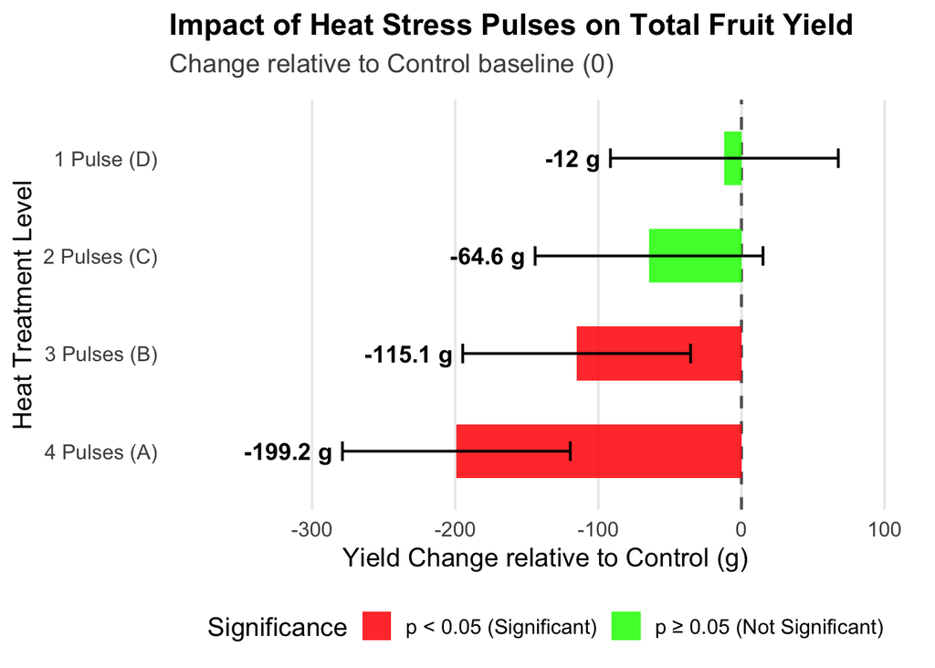

## Model 2: Healthy fruit weight

```r
m_healthy <- lme(
  healthy_weight ~ year * cultivar + heat_group,
  random=~1 | pair_id,
  data=data_clean, method="ML",
  control=lmeControl(opt="optim")
)
summary(m_healthy)
```

```
## Linear mixed-effects model fit by maximum likelihood
##   Data: data_clean
##        AIC      BIC    logLik
##   1227.758 1253.401 -603.8788
##
## Random effects:
##  Formula: ~1 | pair_id
##         (Intercept) Residual
## StdDev:    4.836727 130.4224
##
## Fixed effects:  healthy_weight ~ year * cultivar + heat_group
##                         Value Std.Error DF  t-value p-value
## (Intercept)         1040.6900  31.12241 44 33.43861  0.0000
## year2025             -46.2088  39.37788 44 -1.17347  0.2469
## cultivarST           -69.4163  39.37788 44 -1.76282  0.0849
## heat_groupA         -240.0105  43.98350 44 -5.45683  0.0000
## heat_groupB         -165.4251  43.98350 44 -3.76107  0.0005
## heat_groupC         -128.5632  43.98350 44 -2.92299  0.0055
## heat_groupD         -115.8446  43.98350 44 -2.63382  0.0116
## year2025:cultivarST -494.8050  55.68873 44 -8.88519  0.0000
##  Correlation:
##                     (Intr) yr2025 cltvST ht_grA ht_grB ht_grC ht_grD
## year2025            -0.633
## cultivarST          -0.633  0.500
## heat_groupA         -0.282  0.000  0.000
## heat_groupB         -0.282  0.000  0.000  0.200
## heat_groupC         -0.282  0.000  0.000  0.200  0.200
## heat_groupD         -0.282  0.000  0.000  0.200  0.200  0.200
## year2025:cultivarST  0.447 -0.707 -0.707  0.000  0.000  0.000  0.000
##
## Standardized Within-Group Residuals:
##          Min           Q1          Med           Q3          Max
## -3.207073487 -0.691853552  0.004383446  0.641748363  2.728439672
##
## Number of Observations: 96
## Number of Groups: 48
```

```r
anova(m_healthy, type="marginal")
```

```
##               numDF denDF   F-value p-value
## (Intercept)       1    44 1118.1405  <.0001
## year              1    44    1.3770  0.2469
## cultivar          1    44    3.1075  0.0849
## heat_group        4    44   10.0428  <.0001
## year:cultivar     1    44   78.9466  <.0001
```

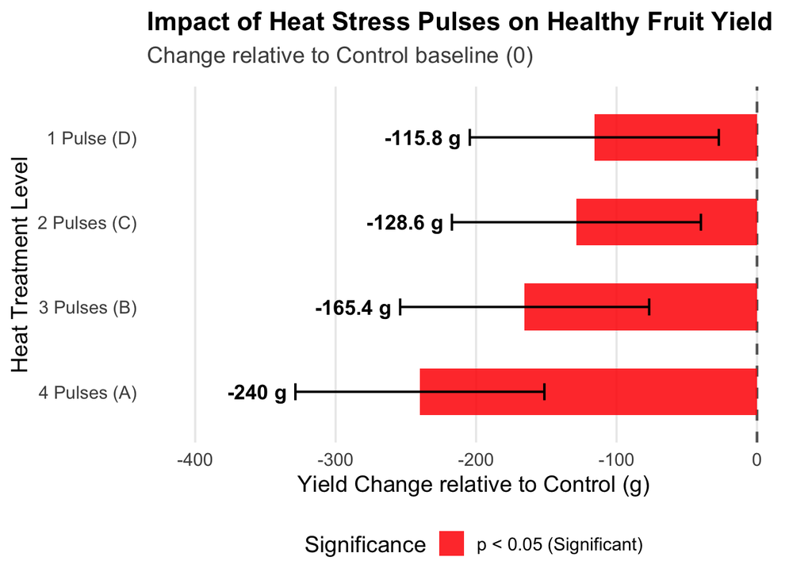

```r
plot_heat_effects(
  model = m_healthy,
  title = "Impact of Heat Stress Pulses on Healthy Fruit Yield",
  unit = "g"
)
```

## Model 2.1: Rotten fruit weight

```r
m_rotten <- lme(
  rotten_weight ~ year * cultivar + heat_group,
  random=~1 | pair_id,
  data=data_clean, method="ML",
  control=lmeControl(opt="optim")
)
summary(m_rotten)
```

```
## Linear mixed-effects model fit by maximum likelihood
##   Data: data_clean
##        AIC      BIC    logLik
##   1019.052 1044.695 -499.5258
##
## Random effects:
##  Formula: ~1 | pair_id
##         (Intercept) Residual
## StdDev:   0.9526044 44.00139
##
## Fixed effects:  rotten_weight ~ year * cultivar + heat_group
##                         Value Std.Error DF   t-value p-value
## (Intercept)          51.57118  10.49235 44  4.915121  0.0000
## year2025            -10.92292  13.27313 44 -0.822934  0.4150
## cultivarST          -39.30721  13.27313 44 -2.961411  0.0049
## heat_groupA          38.89691  14.83495 44  2.621978  0.0120
## heat_groupB          49.48626  14.83495 44  3.335789  0.0017
## heat_groupC          65.50840  14.83495 44  4.415815  0.0001
## heat_groupD         105.08568  14.83495 44  7.083655  0.0000
## year2025:cultivarST -14.76613  18.77105 44 -0.786644  0.4357
##  Correlation:
##                     (Intr) yr2025 cltvST ht_grA ht_grB ht_grC ht_grD
## year2025            -0.633
## cultivarST          -0.633  0.500
## heat_groupA         -0.283  0.000  0.000
## heat_groupB         -0.283  0.000  0.000  0.200
## heat_groupC         -0.283  0.000  0.000  0.200  0.200
## heat_groupD         -0.283  0.000  0.000  0.200  0.200  0.200
## year2025:cultivarST  0.447 -0.707 -0.707  0.000  0.000  0.000  0.000
##
## Standardized Within-Group Residuals:
##        Min         Q1        Med         Q3        Max
## -2.2754001 -0.4770939 -0.1385476  0.3442299  3.9556515
##
## Number of Observations: 96
## Number of Groups: 48
```

```r
anova(m_rotten, type="marginal")
```

```
##               numDF denDF   F-value p-value
## (Intercept)       1    44 24.158413  <.0001
## year              1    44  0.677221  0.4150
## cultivar          1    44  8.769955  0.0049
## heat_group        4    44 15.498130  <.0001
## year:cultivar     1    44  0.618808  0.4357
```

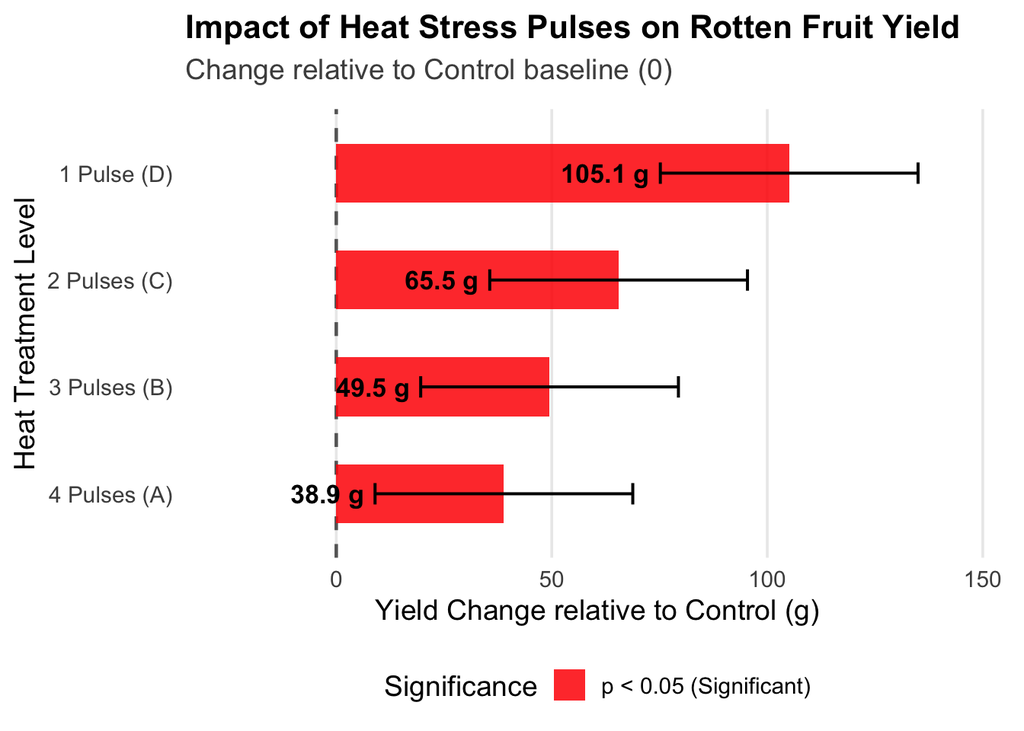

```r
plot_heat_effects(
  model = m_rotten,
  title = "Impact of Heat Stress Pulses on Rotten Fruit Yield",
  unit = "g"
)
```

## Model 3: Healthy percentage by count

```r
m_count_pct <- lme(
  healthy_count_pct ~ year * cultivar + heat_group,
  random=~1 | pair_id,
  data=data_clean, method="ML",
  control=lmeControl(opt="optim")
)
summary(m_count_pct)
```

```
## Linear mixed-effects model fit by maximum likelihood
##   Data: data_clean
##        AIC      BIC   logLik
##   644.5681 670.2116 -312.284
##
## Random effects:
##  Formula: ~1 | pair_id
##         (Intercept) Residual
## StdDev:   0.1800229 6.256411
##
## Fixed effects:  healthy_count_pct ~ year * cultivar + heat_group
##                         Value Std.Error DF  t-value p-value
## (Intercept)          95.44009  1.492301 44 63.95499  0.0000
## year2025             -1.41609  1.887940 44 -0.75007  0.4572
## cultivarST            2.09195  1.887940 44  1.10806  0.2739
## heat_groupA         -13.57434  2.109559 44 -6.43468  0.0000
## heat_groupB         -11.91185  2.109559 44 -5.64661  0.0000
## heat_groupC         -11.41860  2.109559 44 -5.41279  0.0000
## heat_groupD         -12.37439  2.109559 44 -5.86587  0.0000
## year2025:cultivarST  -1.96047  2.669950 44 -0.73427  0.4667
##  Correlation:
##                     (Intr) yr2025 cltvST ht_grA ht_grB ht_grC ht_grD
## year2025            -0.633
## cultivarST          -0.633  0.500
## heat_groupA         -0.283  0.000  0.000
## heat_groupB         -0.283  0.000  0.000  0.200
## heat_groupC         -0.283  0.000  0.000  0.200  0.200
## heat_groupD         -0.283  0.000  0.000  0.200  0.200  0.200
## year2025:cultivarST  0.447 -0.707 -0.707  0.000  0.000  0.000  0.000
##
## Standardized Within-Group Residuals:
##         Min          Q1         Med          Q3         Max
## -4.15791786 -0.39276701  0.04693103  0.45913676  2.27893609
##
## Number of Observations: 96
## Number of Groups: 48
```

```r
anova(m_count_pct, type="marginal")
```

```
##               numDF denDF  F-value p-value
## (Intercept)       1    44 4090.241  <.0001
## year              1    44    0.563  0.4572
## cultivar          1    44    1.228  0.2739
## heat_group        4    44   21.506  <.0001
## year:cultivar     1    44    0.539  0.4667
```

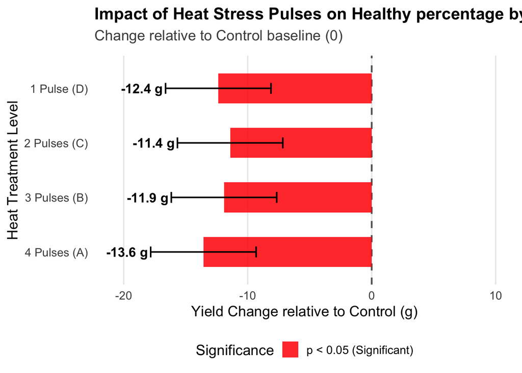

```r
plot_heat_effects(
  model = m_count_pct,
  title = "Impact of Heat Stress Pulses on Healthy percentage by count",
  unit = "g"
)
```

## Model 3.1: Rotten percentage by count

```r
m_rotten_count_pct <- lme(
  rotten_count_pct ~ year * cultivar + heat_group,
  random=~1 | pair_id,
  data=data_clean, method="ML",
  control=lmeControl(opt="optim")
)
summary(m_rotten_count_pct)
```

```
## Linear mixed-effects model fit by maximum likelihood
##   Data: data_clean
##        AIC      BIC   logLik
##   644.5681 670.2116 -312.284
##
## Random effects:
##  Formula: ~1 | pair_id
##         (Intercept) Residual
## StdDev:   0.1800229 6.256411
##
## Fixed effects:  rotten_count_pct ~ year * cultivar + heat_group
##                         Value Std.Error DF   t-value p-value
## (Intercept)          4.559915  1.492301 44  3.055627  0.0038
## year2025             1.416093  1.887940 44  0.750073  0.4572
## cultivarST          -2.091950  1.887940 44 -1.108060  0.2739
## heat_groupA         13.574342  2.109559 44  6.434682  0.0000
## heat_groupB         11.911850  2.109559 44  5.646607  0.0000
## heat_groupC         11.418598  2.109559 44  5.412789  0.0000
## heat_groupD         12.374394  2.109559 44  5.865868  0.0000
## year2025:cultivarST  1.960475  2.669950 44  0.734274  0.4667
##  Correlation:
##                     (Intr) yr2025 cltvST ht_grA ht_grB ht_grC ht_grD
## year2025            -0.633
## cultivarST          -0.633  0.500
## heat_groupA         -0.283  0.000  0.000
## heat_groupB         -0.283  0.000  0.000  0.200
## heat_groupC         -0.283  0.000  0.000  0.200  0.200
## heat_groupD         -0.283  0.000  0.000  0.200  0.200  0.200
## year2025:cultivarST  0.447 -0.707 -0.707  0.000  0.000  0.000  0.000
##
## Standardized Within-Group Residuals:
##         Min          Q1         Med          Q3         Max
## -2.27893609 -0.45913676 -0.04693103  0.39276701  4.15791786
##
## Number of Observations: 96
## Number of Groups: 48
```

```r
anova(m_rotten_count_pct, type="marginal")
```

```
##               numDF denDF   F-value p-value
## (Intercept)       1    44  9.336857  0.0038
## year              1    44  0.562610  0.4572
## cultivar          1    44  1.227797  0.2739
## heat_group        4    44 21.505869  <.0001
## year:cultivar     1    44  0.539158  0.4667
```

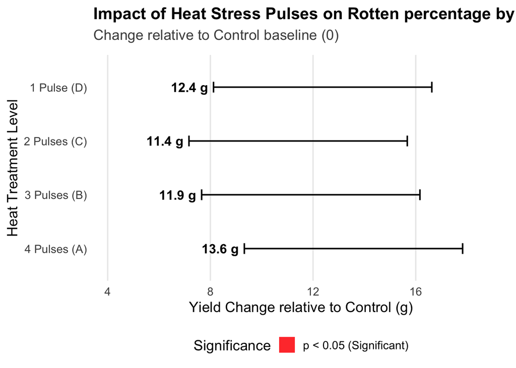

```r
plot_heat_effects(
  model = m_rotten_count_pct,
  title = "Impact of Heat Stress Pulses on Rotten percentage by count",
  unit = "g"
)
```

## Model 4: Healthy percentage by weight

```r
m_weight_pct <- lme(
  healthy_weight_pct ~ year * cultivar + heat_group,
  random=~1 | pair_id,
  data=data_clean, method="ML",
  control=lmeControl(opt="optim")
)
summary(m_weight_pct)
```

```
## Linear mixed-effects model fit by maximum likelihood
##   Data: data_clean
##        AIC      BIC    logLik
##   599.8058 625.4493 -289.9029
##
## Random effects:
##  Formula: ~1 | pair_id
##         (Intercept) Residual
## StdDev:   0.1387742 4.955467
##
## Fixed effects:  healthy_weight_pct ~ year * cultivar + heat_group
##                         Value Std.Error DF  t-value p-value
## (Intercept)          96.00381  1.181954 44 81.22467  0.0000
## year2025              0.46825  1.495301 44  0.31315  0.7556
## cultivarST            3.12937  1.495301 44  2.09280  0.0422
## heat_groupA          -6.60788  1.670880 44 -3.95473  0.0003
## heat_groupB          -7.44320  1.670880 44 -4.45466  0.0001
## heat_groupC          -8.40984  1.670880 44 -5.03318  0.0000
## heat_groupD         -12.15885  1.670880 44 -7.27691  0.0000
## year2025:cultivarST  -0.39674  2.114675 44 -0.18761  0.8520
##  Correlation:
##                     (Intr) yr2025 cltvST ht_grA ht_grB ht_grC ht_grD
## year2025            -0.633
## cultivarST          -0.633  0.500
## heat_groupA         -0.283  0.000  0.000
## heat_groupB         -0.283  0.000  0.000  0.200
## heat_groupC         -0.283  0.000  0.000  0.200  0.200
## heat_groupD         -0.283  0.000  0.000  0.200  0.200  0.200
## year2025:cultivarST  0.447 -0.707 -0.707  0.000  0.000  0.000  0.000
##
## Standardized Within-Group Residuals:
##        Min         Q1        Med         Q3        Max
## -4.7285205 -0.3038007  0.0912741  0.3696008  2.3613791
##
## Number of Observations: 96
## Number of Groups: 48
```

```r
anova(m_weight_pct, type="marginal")
```

```
##               numDF denDF  F-value p-value
## (Intercept)       1    44 6597.447  <.0001
## year              1    44    0.098  0.7556
## cultivar          1    44    4.380  0.0422
## heat_group        4    44   18.791  <.0001
## year:cultivar     1    44    0.035  0.8520
```

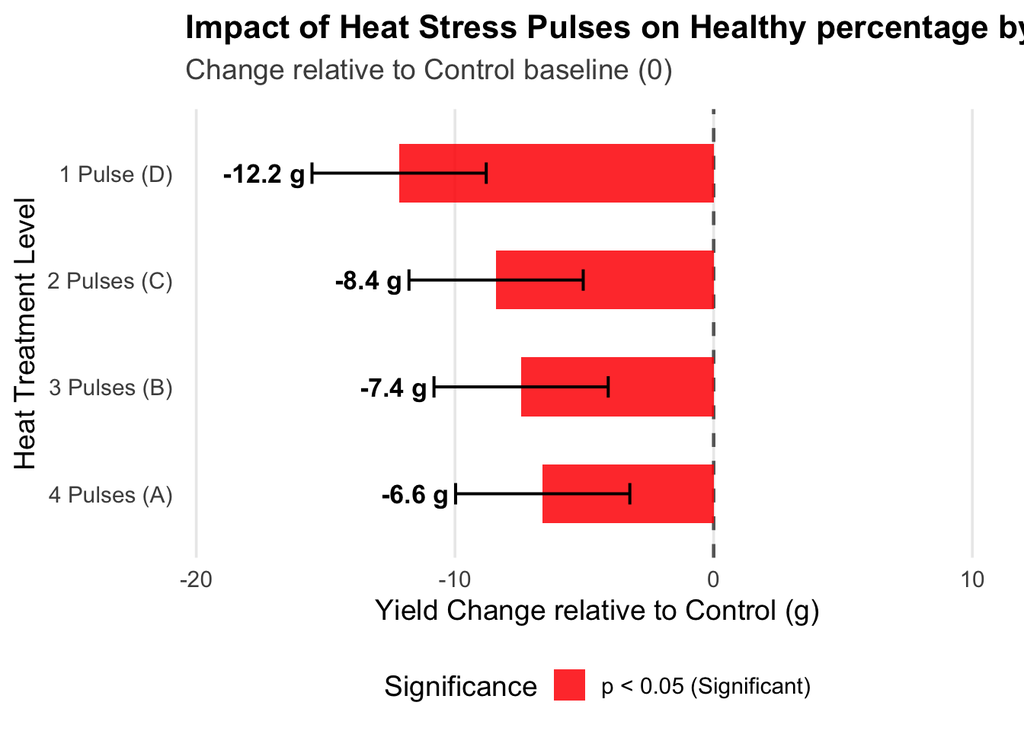

```r
plot_heat_effects(
  model = m_weight_pct,
  title = "Impact of Heat Stress Pulses on Healthy percentage by weight",
  unit = "g"
)
```

## Model 4.1: Rotten percentage by weight

```r
m_rotten_pct <- lme(
  rotten_weight_pct ~ year * cultivar + heat_group,
  random=~1 | pair_id,
  data=data_clean, method="ML",
  control=lmeControl(opt="optim")
)
summary(m_rotten_pct)
```

```
## Linear mixed-effects model fit by maximum likelihood
##   Data: data_clean
##        AIC      BIC    logLik
##   599.8058 625.4493 -289.9029
##
## Random effects:
##  Formula: ~1 | pair_id
##         (Intercept) Residual
## StdDev:   0.1387742 4.955467
##
## Fixed effects:  rotten_weight_pct ~ year * cultivar + heat_group
##                         Value Std.Error DF   t-value p-value
## (Intercept)          3.996187  1.181954 44  3.381001  0.0015
## year2025            -0.468250  1.495301 44 -0.313148  0.7556
## cultivarST          -3.129369  1.495301 44 -2.092803  0.0422
## heat_groupA          6.607877  1.670880 44  3.954728  0.0003
## heat_groupB          7.443199  1.670880 44  4.454658  0.0001
## heat_groupC          8.409839  1.670880 44  5.033179  0.0000
## heat_groupD         12.158847  1.670880 44  7.276912  0.0000
## year2025:cultivarST  0.396737  2.114675 44  0.187611  0.8520
##  Correlation:
##                     (Intr) yr2025 cltvST ht_grA ht_grB ht_grC ht_grD
## year2025            -0.633
## cultivarST          -0.633  0.500
## heat_groupA         -0.283  0.000  0.000
## heat_groupB         -0.283  0.000  0.000  0.200
## heat_groupC         -0.283  0.000  0.000  0.200  0.200
## heat_groupD         -0.283  0.000  0.000  0.200  0.200  0.200
## year2025:cultivarST  0.447 -0.707 -0.707  0.000  0.000  0.000  0.000
##
## Standardized Within-Group Residuals:
##        Min         Q1        Med         Q3        Max
## -2.3613791 -0.3696008 -0.0912741  0.3038007  4.7285205
##
## Number of Observations: 96
## Number of Groups: 48
```

```r
anova(m_rotten_pct, type="marginal")
```

```
##               numDF denDF   F-value p-value
## (Intercept)       1    44 11.431167  0.0015
## year              1    44  0.098062  0.7556
## cultivar          1    44  4.379822  0.0422
## heat_group        4    44 18.791034  <.0001
## year:cultivar     1    44  0.035198  0.8520
```

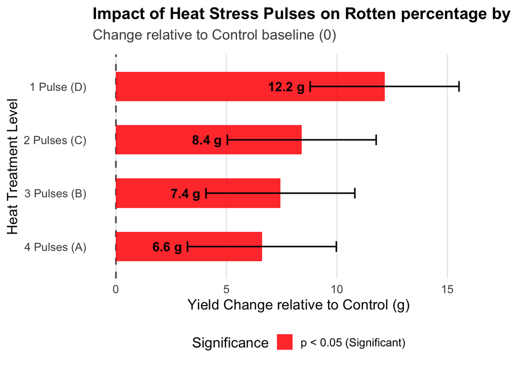

```r
plot_heat_effects(
  model = m_rotten_pct,
  title = "Impact of Heat Stress Pulses on Rotten percentage by weight",
  unit = "g"
)
```

## A-D versus the common Control

In the additive models, heat_group coefficients are adjusted A-D minus Control differences, assumed common across years and cultivars. Weights are in grams; healthy percentage differences are in percentage points. Intervals are pointwise. Holm p values are adjusted across the four contrasts within each response.

```r
models <- list(total_weight=m_total, healthy_weight=m_healthy,
               healthy_count_pct=m_count_pct, healthy_weight_pct=m_weight_pct)
effects <- do.call(rbind, lapply(names(models), function(name) {
  fit <- models[[name]]
  tab <- summary(fit)$tTable
  tab <- tab[grepl("^heat_group", rownames(tab)), , drop=FALSE]
  data.frame(outcome=name,
    comparison=paste(sub("heat_group", "", rownames(tab)), "- Control"),
    estimate=tab[, "Value"],
    lower=tab[, "Value"] - qt(.975, tab[, "DF"]) * tab[, "Std.Error"],
    upper=tab[, "Value"] + qt(.975, tab[, "DF"]) * tab[, "Std.Error"],
    p_value=tab[, "p-value"],
    p_holm=p.adjust(tab[, "p-value"], method="holm"), row.names=NULL)
}))
knitr::kable(effects, digits=4)
```

| outcome | comparison | estimate | lower | upper | p_value | p_holm |
| --- | --- | --- | --- | --- | --- | --- |
| total_weight | A - Control | -199.2151 | -278.8241 | -119.6061 | 0.0000 | 0.0000 |
| total_weight | B - Control | -115.1434 | -194.7524 | -35.5344 | 0.0056 | 0.0167 |
| total_weight | C - Control | -64.5545 | -144.1635 | 15.0545 | 0.1093 | 0.2187 |
| total_weight | D - Control | -11.9531 | -91.5622 | 67.6559 | 0.7636 | 0.7636 |
| healthy_weight | A - Control | -240.0105 | -328.6534 | -151.3675 | 0.0000 | 0.0000 |
| healthy_weight | B - Control | -165.4251 | -254.0680 | -76.7822 | 0.0005 | 0.0015 |
| healthy_weight | C - Control | -128.5632 | -217.2061 | -39.9202 | 0.0055 | 0.0109 |
| healthy_weight | D - Control | -115.8446 | -204.4875 | -27.2017 | 0.0116 | 0.0116 |
| healthy_count_pct | A - Control | -13.5743 | -17.8259 | -9.3228 | 0.0000 | 0.0000 |
| healthy_count_pct | B - Control | -11.9119 | -16.1634 | -7.6603 | 0.0000 | 0.0000 |
| healthy_count_pct | C - Control | -11.4186 | -15.6701 | -7.1671 | 0.0000 | 0.0000 |
| healthy_count_pct | D - Control | -12.3744 | -16.6259 | -8.1229 | 0.0000 | 0.0000 |
| healthy_weight_pct | A - Control | -6.6079 | -9.9753 | -3.2404 | 0.0003 | 0.0003 |
| healthy_weight_pct | B - Control | -7.4432 | -10.8106 | -4.0758 | 0.0001 | 0.0001 |
| healthy_weight_pct | C - Control | -8.4098 | -11.7773 | -5.0424 | 0.0000 | 0.0000 |
| healthy_weight_pct | D - Control | -12.1588 | -15.5263 | -8.7914 | 0.0000 | 0.0000 |

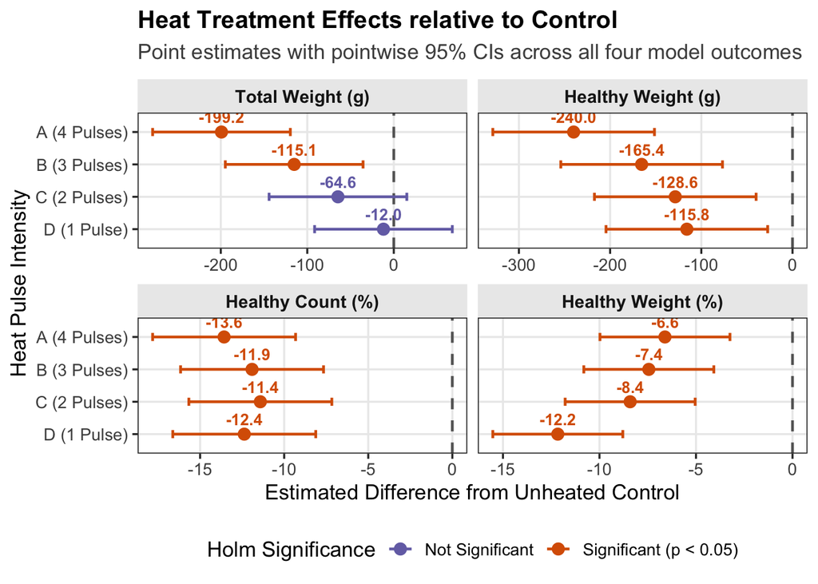

```r
# 1. Format the 'effects' data frame for plotting
effects_plot_data <- effects %>%
  # Support column names from both base-R (lower/upper) and broom (conf.low/conf.high)
  mutate(
    ci_lower = if ("lower" %in% names(.)) lower else conf.low,
    ci_upper = if ("upper" %in% names(.)) upper else conf.high,
    p_adj    = if ("p_holm" %in% names(.)) p_holm else p_value,

    # Human-readable panel headers
    outcome_label = factor(outcome,
      levels = c("total_weight", "healthy_weight", "healthy_count_pct", "healthy_weight_pct"),
      labels = c("Total Weight (g)", "Healthy Weight (g)", "Healthy Count (%)", "Healthy Weight (%)")
    ),

    # Clean group order: D (1 pulse) at top to A (4 pulses) at bottom
    comparison_label = factor(comparison,
      levels = c("D - Control", "C - Control", "B - Control", "A - Control"),
      labels = c("D (1 Pulse)", "C (2 Pulses)", "B (3 Pulses)", "A (4 Pulses)")
    ),

    # Significance indicator after Holm correction
    sig_status = ifelse(p_adj < 0.05, "Significant (p < 0.05)", "Not Significant")
  )

# 2. Build the Multi-Panel Forest Plot
ggplot(effects_plot_data, aes(x = estimate, y = comparison_label, color = sig_status)) +
  # Reference line at 0 (No effect compared to Control)
  geom_vline(xintercept = 0, linetype = "dashed", color = "gray40", linewidth = 0.8) +
  # 95% Confidence Interval error bars
  geom_errorbarh(aes(xmin = ci_lower, xmax = ci_upper), height = 0.25, linewidth = 0.8) +
  # Point estimates
  geom_point(size = 3) +
  # Numerical text labels above points
  geom_text(
    aes(label = sprintf("%.1f", estimate)),
    vjust = -0.8, size = 3.5, fontface = "bold", show.legend = FALSE
  ) +
  # Facet by model outcome with independent x-axis scales (grams vs. %)
  facet_wrap(~ outcome_label, scales = "free_x", ncol = 2) +
  scale_color_manual(values = c(
    "Significant (p < 0.05)" = "#d95f02",
    "Not Significant" = "#7570b3"
  )) +
  labs(
    title = "Heat Treatment Effects relative to Control",
    subtitle = "Point estimates with pointwise 95% CIs across all four model outcomes",
    x = "Estimated Difference from Unheated Control",
    y = "Heat Pulse Intensity",
    color = "Holm Significance"
  ) +
  theme_bw(base_size = 13) +
  theme(
    plot.title = element_text(face = "bold", size = 15),
    plot.subtitle = element_text(color = "gray30", margin = margin(b = 10)),
    strip.background = element_rect(fill = "gray92", color = NA),
    strip.text = element_text(face = "bold", size = 11),
    legend.position = "bottom",
    panel.grid.minor = element_blank()
  )
```

### Does the heat response differ between cultivars?

These candidate models retain a common Control category but allow the A-D effects to vary by cultivar. Compare fixed effects using ML; do not automatically select a model based on one p value.

```r
m_total_cultivar <- update(m_total, . ~ . + heat_group:cultivar)
m_healthy_cultivar <- update(m_healthy, . ~ . + heat_group:cultivar)
m_count_pct_cultivar <- update(m_count_pct, . ~ . + heat_group:cultivar)
m_weight_pct_cultivar <- update(m_weight_pct, . ~ . + heat_group:cultivar)
m_rotten_pct_cultivar <- update(m_rotten_pct, . ~ . + heat_group:cultivar)

anova(m_total, m_total_cultivar)
```

```
##                  Model df      AIC      BIC    logLik   Test  L.Ratio p-value
## m_total              1 10 1209.806 1235.449 -594.9029
## m_total_cultivar     2 14 1205.532 1241.432 -588.7658 1 vs 2 12.27409  0.0154
```

```r
anova(m_healthy, m_healthy_cultivar)
```

```
##                    Model df      AIC      BIC    logLik   Test  L.Ratio p-value
## m_healthy              1 10 1227.757 1253.401 -603.8788
## m_healthy_cultivar     2 14 1222.937 1258.838 -597.4685 1 vs 2 12.82046  0.0122
```

```r
anova(m_count_pct, m_count_pct_cultivar)
```

```
##                      Model df      AIC      BIC    logLik   Test  L.Ratio
## m_count_pct              1 10 644.5681 670.2116 -312.2840
## m_count_pct_cultivar     2 14 651.0624 686.9632 -311.5312 1 vs 2 1.505728
##                      p-value
## m_count_pct
## m_count_pct_cultivar  0.8256
```

```r
anova(m_weight_pct, m_weight_pct_cultivar)
```

```
##                       Model df      AIC      BIC    logLik   Test  L.Ratio
## m_weight_pct              1 10 599.8058 625.4493 -289.9029
## m_weight_pct_cultivar     2 14 606.0326 641.9335 -289.0163 1 vs 2 1.773128
##                       p-value
## m_weight_pct
## m_weight_pct_cultivar  0.7774
```

```r
anova(m_rotten_pct, m_rotten_pct_cultivar)
```

```
##                       Model df      AIC      BIC    logLik   Test  L.Ratio
## m_rotten_pct              1 10 599.8058 625.4493 -289.9029
## m_rotten_pct_cultivar     2 14 606.0326 641.9335 -289.0163 1 vs 2 1.773128
##                       p-value
## m_rotten_pct
## m_rotten_pct_cultivar  0.7774
```

```r
library(emmeans)
library(ggplot2)
library(dplyr)

plot_emmeans_by_cultivar <- function(
  model,
  x_var = "heat_group",
  facet_var = "cultivar",
  x_order = c("Control", "D", "C", "B", "A"),
  x_labels = c("Control (0)", "D (1 Pulse)", "C (2 Pulses)", "B (3 Pulses)", "A (4 Pulses)"),
  title = "Fruit Response to Heat Pulses by Cultivar",
  subtitle = "Interaction model adjusted means ± 95% CI",
  xlab = "Heat Treatment Scheme",
  ylab = "Adjusted Weight",
  unit = "g",
  base_size = 13
) {
  # 1. Construct formula dynamically (~ x_var | facet_var)
  emm_formula <- as.formula(paste("~", x_var, "|", facet_var))

  # 2. Extract EMMs as a data frame
  emm_df <- as.data.frame(emmeans(model, emm_formula))

  # 3. Dynamic CI column detection (handles lower.CL/upper.CL or asym.LCL/asym.UCL)
  lower_col <- names(emm_df)[grep("lower|LCL", names(emm_df), ignore.case = TRUE)][1]
  upper_col <- names(emm_df)[grep("upper|UCL", names(emm_df), ignore.case = TRUE)][1]

  emm_df$lower_ci <- emm_df[[lower_col]]
  emm_df$upper_ci <- emm_df[[upper_col]]

  # Assign standardized variables for plotting
  emm_df$x_val <- emm_df[[x_var]]
  emm_df$facet_val <- emm_df[[facet_var]]

  # 4. Reorder and relabel X-axis factor levels logically
  if (!is.null(x_order)) {
    existing_levels <- levels(factor(emm_df$x_val))
    valid_order <- intersect(x_order, existing_levels)

    if (length(valid_order) > 0) {
      emm_df$x_val <- factor(emm_df$x_val, levels = valid_order)
      if (!is.null(x_labels) && length(x_labels) == length(valid_order)) {
        levels(emm_df$x_val) <- x_labels
      }
    }
  }

  # 5. Build ggplot
  y_title <- if (nzchar(unit)) paste0(ylab, " (", unit, ")") else ylab

  ggplot(emm_df, aes(x = x_val, y = emmean, group = facet_val, color = facet_val)) +
    geom_line(linewidth = 1) +
    geom_point(size = 3) +
    geom_errorbar(aes(ymin = lower_ci, ymax = upper_ci), width = 0.15, linewidth = 0.7) +
    facet_wrap(~ facet_val) +
    labs(
      title = title,
      subtitle = subtitle,
      x = xlab,
      y = y_title
    ) +
    theme_bw(base_size = base_size) +
    theme(
      plot.title = element_text(face = "bold"),
      legend.position = "none",
      axis.text.x = element_text(angle = 30, hjust = 1)
    )
}
```

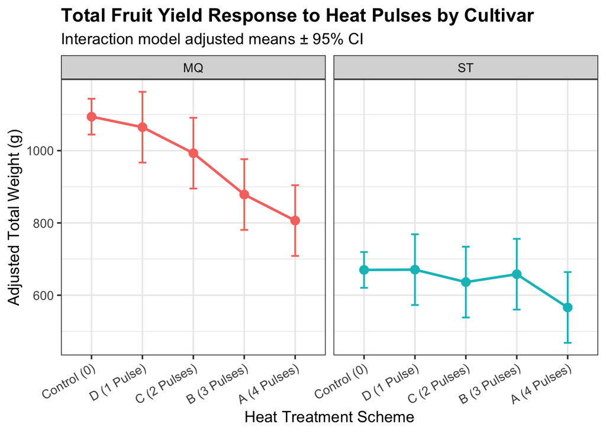

```r
plot_emmeans_by_cultivar(
  model = m_total_cultivar,
  title = "Total Fruit Yield Response to Heat Pulses by Cultivar",
  ylab = "Adjusted Total Weight",
  unit = "g"
)
```

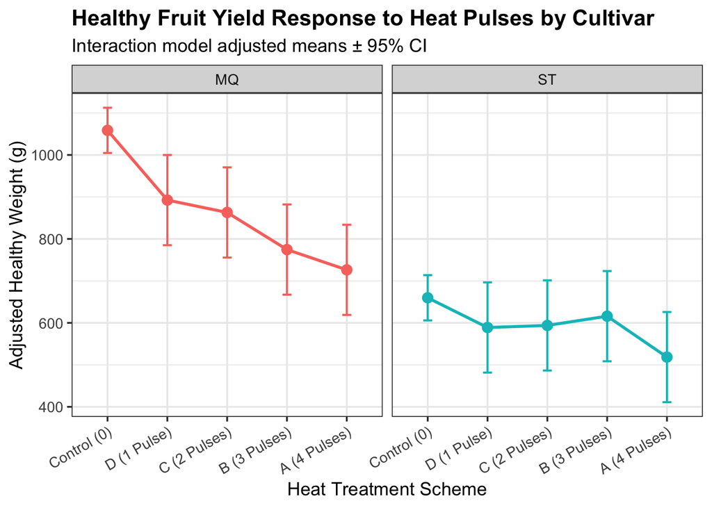

```r
plot_emmeans_by_cultivar(
  model = m_healthy_cultivar,
  title = "Healthy Fruit Yield Response to Heat Pulses by Cultivar",
  ylab = "Adjusted Healthy Weight",
  unit = "g"
)
```

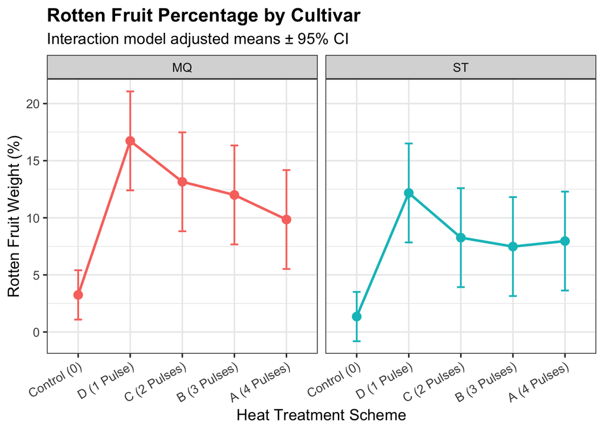

```r
plot_emmeans_by_cultivar(
  model = m_rotten_pct_cultivar,
  title = "Rotten Fruit Percentage by Cultivar",
  ylab = "Rotten Fruit Weight",
  unit = "%"
)
```

## Intensity comparisons: A-D

A, B, C and D correspond to 4, 3, 2 and 1 heat pulses. Weight outcomes use the cultivar-interaction models; percentage outcomes use additive models. Means are averaged equally over years (and cultivars for percentage outcomes). Controls remain pooled within each year and cultivar. Comparisons use Holm correction for the six A-D pairs within each outcome/cultivar; confidence intervals are pointwise 95%, not simultaneous. Degrees of freedom use a conservative minimum over the fixed coefficients involved.

```r
# No additional packages are required.
intensity_results <- function(fit, cultivar_level=NULL) {
  grid <- expand.grid(
    year=levels(data_clean$year),
    cultivar=if (is.null(cultivar_level)) levels(data_clean$cultivar) else cultivar_level,
    heat_group=levels(data_clean$heat_group)
  )
  grid$year <- factor(grid$year, levels=levels(data_clean$year))
  grid$cultivar <- factor(grid$cultivar, levels=levels(data_clean$cultivar))
  grid$heat_group <- factor(grid$heat_group, levels=levels(data_clean$heat_group))
  X <- model.matrix(delete.response(terms(formula(fit))), grid)
  X <- X[, names(fixef(fit)), drop=FALSE]
  mean_X <- do.call(rbind, lapply(levels(data_clean$heat_group), function(g) {
    colMeans(X[grid$heat_group == g, , drop=FALSE])
  }))
  rownames(mean_X) <- levels(data_clean$heat_group)

  estimate_contrast <- function(L) {
    estimate <- as.numeric(L %*% fixef(fit))
    se <- sqrt(as.numeric(L %*% vcov(fit) %*% L))
    df <- min(fit$fixDF$X[abs(L) > 1e-10])
    data.frame(estimate=estimate, SE=se, df=df,
      lower=estimate-qt(.975,df)*se,
      upper=estimate+qt(.975,df)*se,
      p_value=2*pt(-abs(estimate/se),df))
  }
  means <- do.call(rbind, lapply(rownames(mean_X), function(g) {
    cbind(group=g, estimate_contrast(mean_X[g, ]))
  }))
  # Pairwise comparisons ONLY among heated groups.
  pairs <- combn(c("A", "B", "C", "D"), 2, simplify=FALSE)
  comparisons <- do.call(rbind, lapply(pairs, function(g) {
    cbind(comparison=paste(g, collapse=" - "),
      estimate_contrast(mean_X[g[1], ] - mean_X[g[2], ]))
  }))
  comparisons$p_holm <- p.adjust(comparisons$p_value, method="holm")
  list(means=means, comparisons=comparisons)
}

# A-D scheme effects relative to the common Control can also be compared
# by subtracting each scheme's mean_X row from another, as above:
# (A - Control) - (B - Control) = A - B.
```

```r
intensity_models <- list(
  total_weight=m_total_cultivar,
  healthy_weight=m_healthy_cultivar,
  healthy_count_pct=m_count_pct,
  healthy_weight_pct=m_weight_pct
)
intensity_export <- list()

for (outcome in names(intensity_models)) {
  fit <- intensity_models[[outcome]]
  is_weight <- outcome %in% c("total_weight", "healthy_weight")
  groups <- if (is_weight) levels(data_clean$cultivar) else "Both cultivars"
  for (g in groups) {
    result <- intensity_results(fit, if (is_weight) g else NULL)
    cat("\n\n### ", outcome, ": ", g, "\n\n", sep="")
    # A mean-vs-zero p value is not relevant here, so omit it.
    print(knitr::kable(result$means[c("group","estimate","SE","lower","upper")],
      digits=2, caption="Adjusted means and pointwise 95% confidence intervals"))
    cat("\n\n")
    print(knitr::kable(result$comparisons, digits=4,
      caption="A-D comparisons; negative estimates mean the first group is lower"))
    cat("\n\n")

    # Order the plot by pulse count: Control, D, C, B, A.
    z <- result$means[match(c("Control","D","C","B","A"),result$means$group), ]
    plot(0:4, z$estimate, type="b", pch=19, xaxt="n",
      ylim=range(z$lower,z$upper), xlab="Heat pulses",
      ylab=if (is_weight) "Adjusted weight (g)" else "Adjusted healthy percentage (%)",
      main=paste(outcome,g))
    axis(1, at=0:4, labels=c("Control","D: 1","C: 2","B: 3","A: 4"))
    arrows(0:4,z$lower,0:4,z$upper,angle=90,code=3,length=.05)
    # Lines guide the eye; the model treats pulse schemes as categories.
    intensity_export[[paste(outcome,g)]] <- list(means=result$means,
                                                comparisons=result$comparisons)
  }
}
```

### total_weight: MQ

Adjusted means and pointwise 95% confidence intervals

| group | estimate | SE | lower | upper |
| --- | --- | --- | --- | --- |
| Control | 1093.96 | 22.98 | 1047.64 | 1140.28 |
| A | 806.49 | 45.30 | 714.93 | 898.05 |
| B | 878.54 | 45.30 | 786.98 | 970.10 |
| C | 992.98 | 45.30 | 901.42 | 1084.54 |
| D | 1064.85 | 45.30 | 973.29 | 1156.41 |

A-D comparisons; negative estimates mean the first group is lower

| comparison | estimate | SE | df | lower | upper | p_value | p_holm |
| --- | --- | --- | --- | --- | --- | --- | --- |
| A - B | -72.0516 | 63.7546 | 40 | -200.9044 | 56.8011 | 0.2651 | 0.5303 |
| A - C | -186.4932 | 63.7546 | 40 | -315.3460 | -57.6405 | 0.0056 | 0.0282 |
| A - D | -258.3611 | 63.7546 | 40 | -387.2138 | -129.5083 | 0.0002 | 0.0014 |
| B - C | -114.4416 | 63.7546 | 40 | -243.2944 | 14.4112 | 0.0802 | 0.2406 |
| B - D | -186.3094 | 63.7546 | 40 | -315.1622 | -57.4567 | 0.0057 | 0.0282 |
| C - D | -71.8678 | 63.7546 | 40 | -200.7206 | 56.9849 | 0.2664 | 0.5303 |

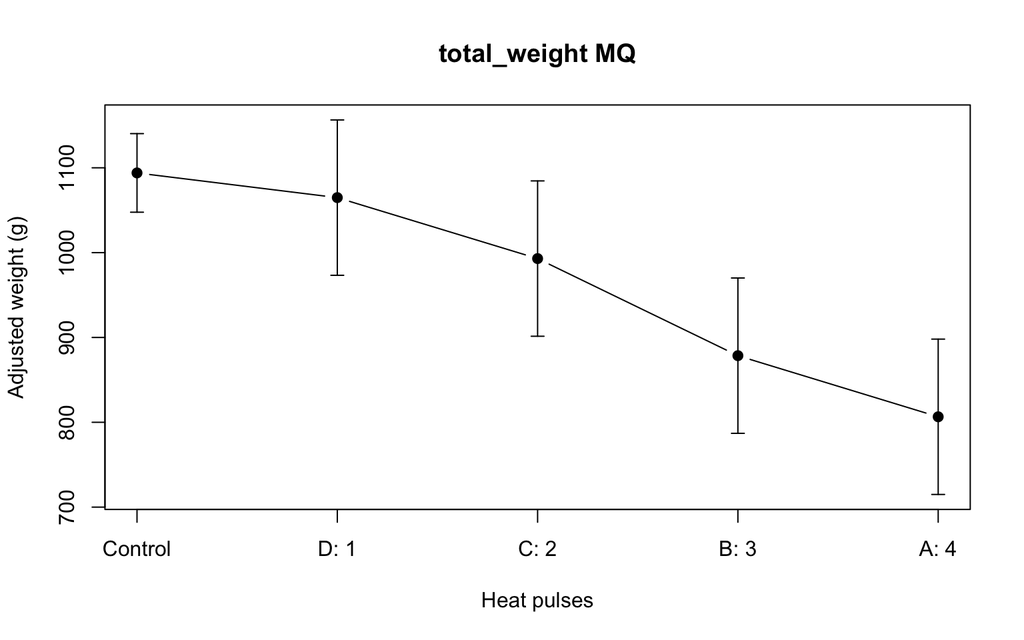

### total_weight: ST

Adjusted means and pointwise 95% confidence intervals

| group | estimate | SE | lower | upper |
| --- | --- | --- | --- | --- |
| Control | 669.92 | 22.98 | 623.61 | 716.24 |
| A | 566.03 | 45.30 | 474.47 | 657.59 |
| B | 658.02 | 45.30 | 566.46 | 749.58 |
| C | 636.22 | 45.30 | 544.66 | 727.78 |
| D | 670.66 | 45.30 | 579.10 | 762.23 |

A-D comparisons; negative estimates mean the first group is lower

| comparison | estimate | SE | df | lower | upper | p_value | p_holm |
| --- | --- | --- | --- | --- | --- | --- | --- |
| A - B | -91.9891 | 63.7546 | 40 | -220.8418 | 36.8637 | 0.1568 | 0.7842 |
| A - C | -70.1847 | 63.7546 | 40 | -199.0374 | 58.6681 | 0.2775 | 1.0000 |
| A - D | -104.6322 | 63.7546 | 40 | -233.4850 | 24.2205 | 0.1086 | 0.6516 |
| B - C | 21.8044 | 63.7546 | 40 | -107.0484 | 150.6572 | 0.7341 | 1.0000 |
| B - D | -12.6431 | 63.7546 | 40 | -141.4959 | 116.2096 | 0.8438 | 1.0000 |
| C - D | -34.4475 | 63.7546 | 40 | -163.3003 | 94.4052 | 0.5920 | 1.0000 |

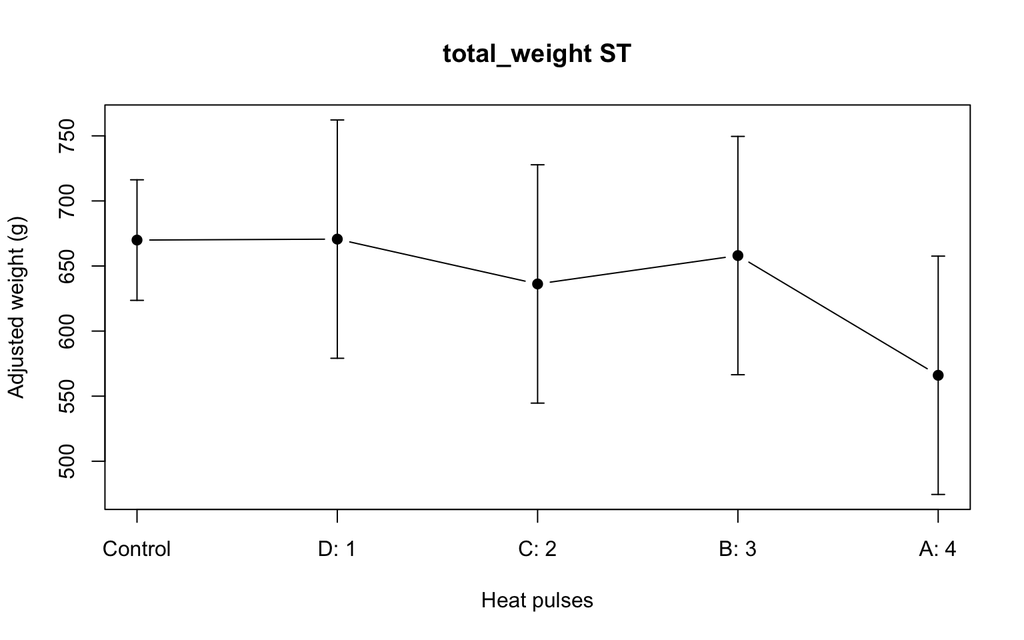

### healthy_weight: MQ

Adjusted means and pointwise 95% confidence intervals

| group | estimate | SE | lower | upper |
| --- | --- | --- | --- | --- |
| Control | 1058.60 | 25.03 | 1008.16 | 1109.04 |
| A | 726.33 | 49.73 | 625.82 | 826.85 |
| B | 774.60 | 49.73 | 674.09 | 875.11 |
| C | 863.03 | 49.73 | 762.52 | 963.55 |
| D | 892.48 | 49.73 | 791.96 | 992.99 |

A-D comparisons; negative estimates mean the first group is lower

| comparison | estimate | SE | df | lower | upper | p_value | p_holm |
| --- | --- | --- | --- | --- | --- | --- | --- |
| A - B | -48.2639 | 70.179 | 40 | -190.1010 | 93.5732 | 0.4956 | 0.9912 |
| A - C | -136.6992 | 70.179 | 40 | -278.5363 | 5.1379 | 0.0585 | 0.2924 |
| A - D | -166.1422 | 70.179 | 40 | -307.9793 | -24.3051 | 0.0228 | 0.1370 |
| B - C | -88.4353 | 70.179 | 40 | -230.2724 | 53.4018 | 0.2149 | 0.6448 |
| B - D | -117.8783 | 70.179 | 40 | -259.7154 | 23.9589 | 0.1008 | 0.4033 |
| C - D | -29.4430 | 70.179 | 40 | -171.2801 | 112.3941 | 0.6771 | 0.9912 |

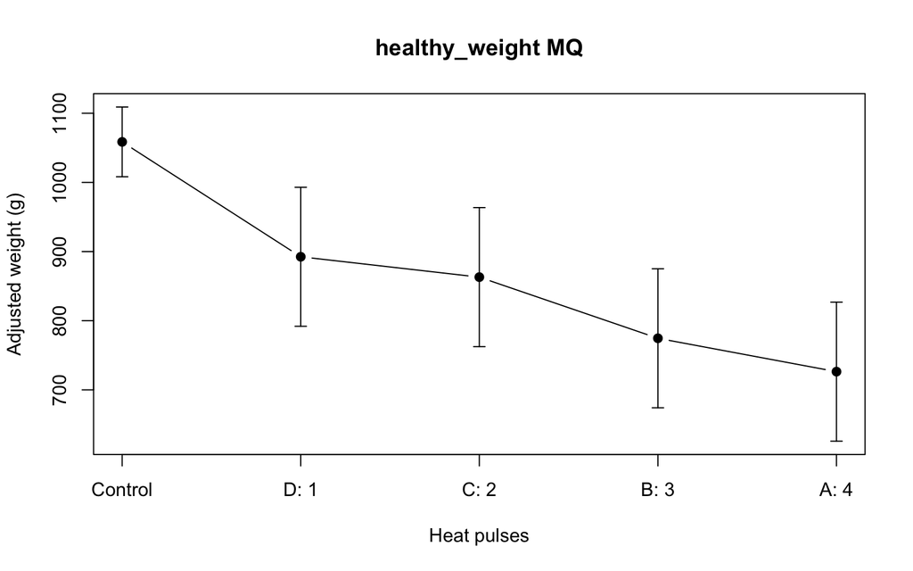

### healthy_weight: ST

Adjusted means and pointwise 95% confidence intervals

| group | estimate | SE | lower | upper |
| --- | --- | --- | --- | --- |
| Control | 659.75 | 25.03 | 609.31 | 710.19 |
| A | 518.45 | 49.73 | 417.93 | 618.96 |
| B | 615.95 | 49.73 | 515.44 | 716.46 |
| C | 593.90 | 49.73 | 493.38 | 694.41 |
| D | 588.99 | 49.73 | 488.48 | 689.50 |

A-D comparisons; negative estimates mean the first group is lower

| comparison | estimate | SE | df | lower | upper | p_value | p_holm |
| --- | --- | --- | --- | --- | --- | --- | --- |
| A - B | -97.5054 | 70.179 | 40 | -239.3425 | 44.3317 | 0.1724 | 1 |
| A - C | -75.4509 | 70.179 | 40 | -217.2880 | 66.3862 | 0.2888 | 1 |
| A - D | -70.5437 | 70.179 | 40 | -212.3808 | 71.2935 | 0.3208 | 1 |
| B - C | 22.0545 | 70.179 | 40 | -119.7826 | 163.8916 | 0.7550 | 1 |
| B - D | 26.9617 | 70.179 | 40 | -114.8754 | 168.7988 | 0.7029 | 1 |
| C - D | 4.9072 | 70.179 | 40 | -136.9299 | 146.7444 | 0.9446 | 1 |

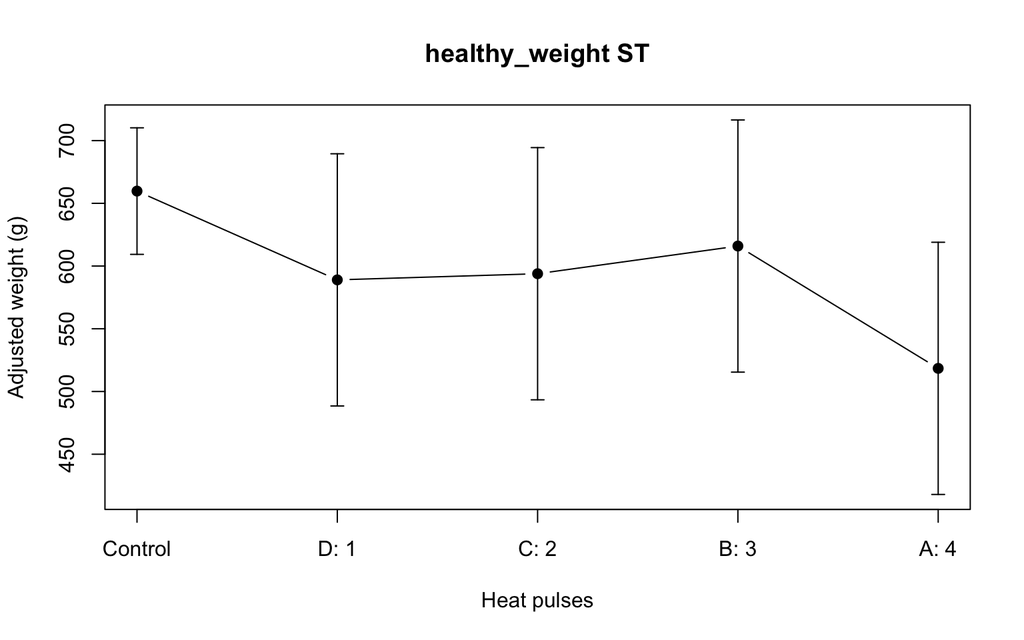

### healthy_count_pct: Both cultivars

Adjusted means and pointwise 95% confidence intervals

| group | estimate | SE | lower | upper |
| --- | --- | --- | --- | --- |
| Control | 95.29 | 0.90 | 93.47 | 97.11 |
| A | 81.71 | 1.81 | 78.07 | 85.35 |
| B | 83.38 | 1.81 | 79.73 | 87.02 |
| C | 83.87 | 1.81 | 80.23 | 87.51 |
| D | 82.91 | 1.81 | 79.27 | 86.55 |

A-D comparisons; negative estimates mean the first group is lower

| comparison | estimate | SE | df | lower | upper | p_value | p_holm |
| --- | --- | --- | --- | --- | --- | --- | --- |
| A - B | -1.6625 | 2.5552 | 44 | -6.8122 | 3.4872 | 0.5187 | 1 |
| A - C | -2.1557 | 2.5552 | 44 | -7.3055 | 2.9940 | 0.4034 | 1 |
| A - D | -1.1999 | 2.5552 | 44 | -6.3497 | 3.9498 | 0.6410 | 1 |
| B - C | -0.4933 | 2.5552 | 44 | -5.6430 | 4.6565 | 0.8478 | 1 |
| B - D | 0.4625 | 2.5552 | 44 | -4.6872 | 5.6123 | 0.8572 | 1 |
| C - D | 0.9558 | 2.5552 | 44 | -4.1939 | 6.1055 | 0.7102 | 1 |

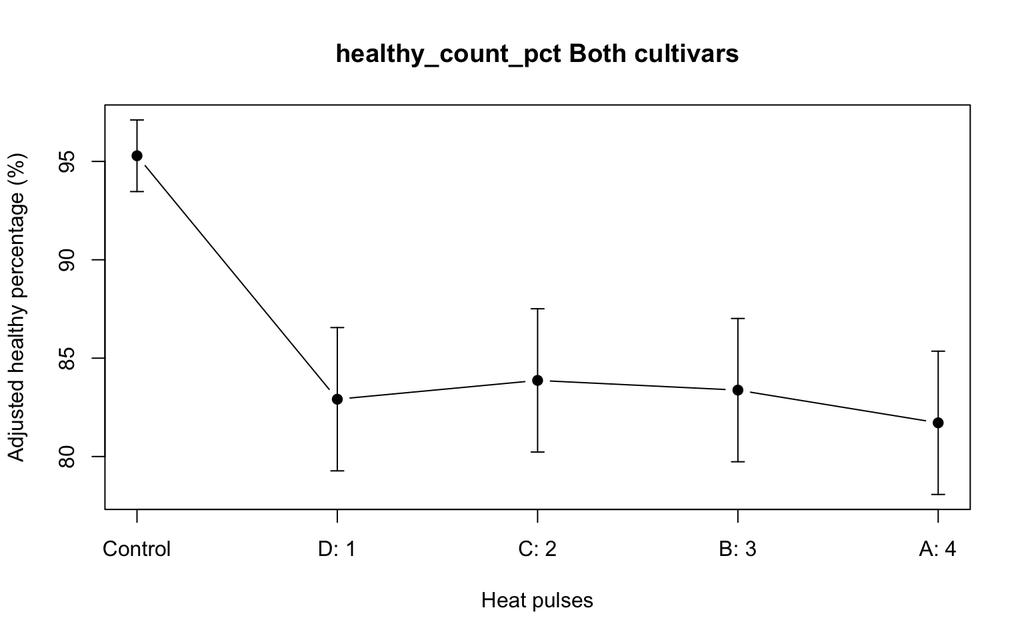

### healthy_weight_pct: Both cultivars

Adjusted means and pointwise 95% confidence intervals

| group | estimate | SE | lower | upper |
| --- | --- | --- | --- | --- |
| Control | 97.70 | 0.72 | 96.26 | 99.15 |
| A | 91.10 | 1.43 | 88.21 | 93.98 |
| B | 90.26 | 1.43 | 87.38 | 93.14 |
| C | 89.29 | 1.43 | 86.41 | 92.18 |
| D | 85.54 | 1.43 | 82.66 | 88.43 |

A-D comparisons; negative estimates mean the first group is lower

| comparison | estimate | SE | df | lower | upper | p_value | p_holm |
| --- | --- | --- | --- | --- | --- | --- | --- |
| A - B | 0.8353 | 2.0239 | 44 | -3.2435 | 4.9141 | 0.6818 | 1.0000 |
| A - C | 1.8020 | 2.0239 | 44 | -2.2768 | 5.8808 | 0.3781 | 1.0000 |
| A - D | 5.5510 | 2.0239 | 44 | 1.4722 | 9.6298 | 0.0088 | 0.0527 |
| B - C | 0.9666 | 2.0239 | 44 | -3.1122 | 5.0454 | 0.6353 | 1.0000 |
| B - D | 4.7156 | 2.0239 | 44 | 0.6368 | 8.7945 | 0.0245 | 0.1223 |
| C - D | 3.7490 | 2.0239 | 44 | -0.3298 | 7.8278 | 0.0707 | 0.2827 |

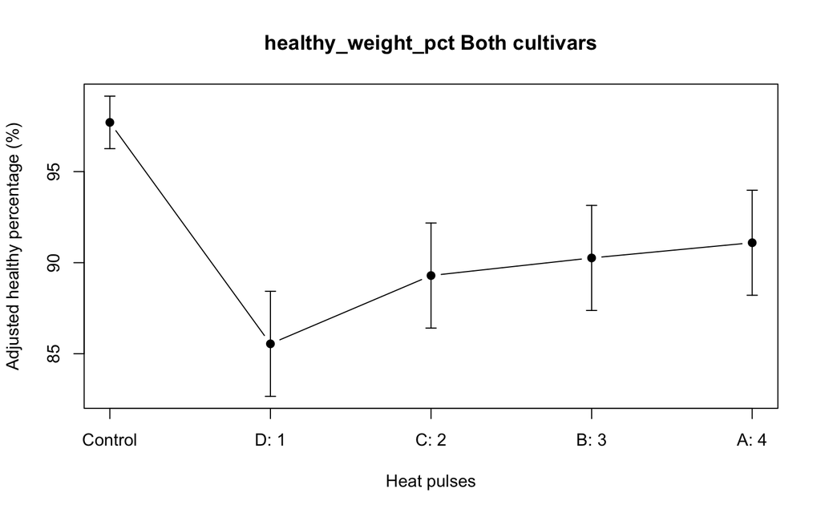

Pulse timing also differs across A-D; these are scheme comparisons, not a confirmed causal effect per additional pulse. The connecting lines do not imply a fitted linear trend. Control has no active heating; its chamber protocol is assumed comparable across the original intensity groups.

### Discuss

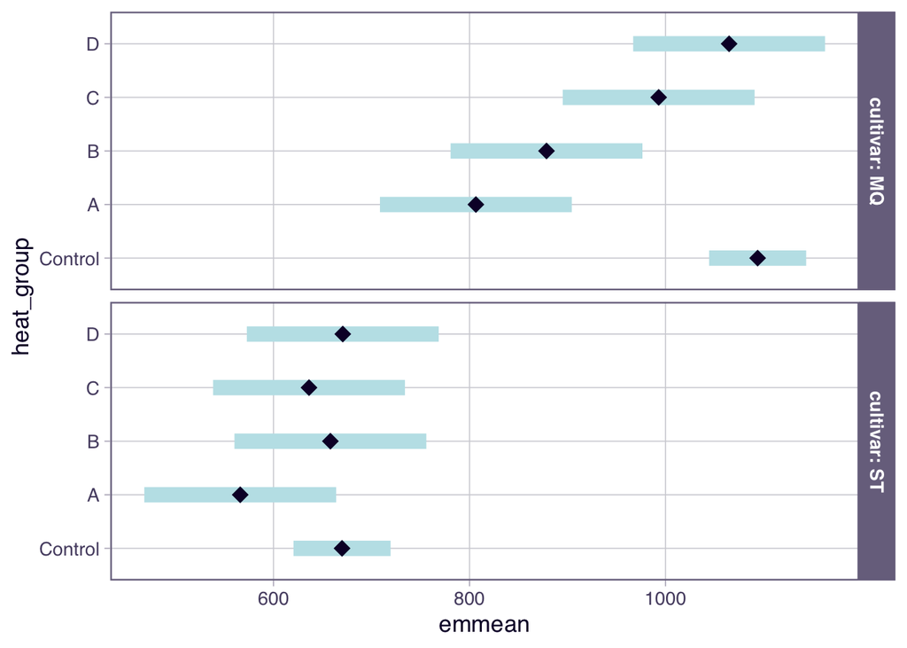

```r
library(emmeans)

# 1. Calculate adjusted marginal means
emms <- emmeans(m_total_cultivar, ~ heat_group | cultivar)

# 2. Pairwise comparisons among A-D (excluding Control) with Holm adjustment
pairs_AD <- contrast(emms, "pairwise", combine = TRUE, adjust = "holm") %>%
  as.data.frame() %>%
  filter(!grepl("Control", contrast))

# 3. Plot dose-response curve
plot(emms)
```

## Diagnostics

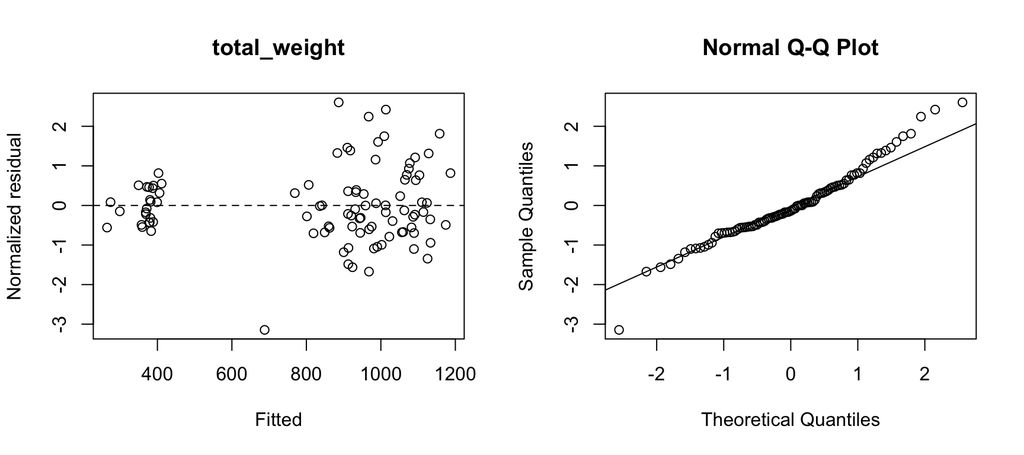

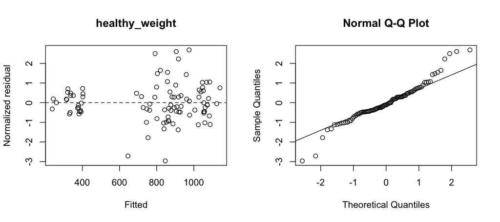

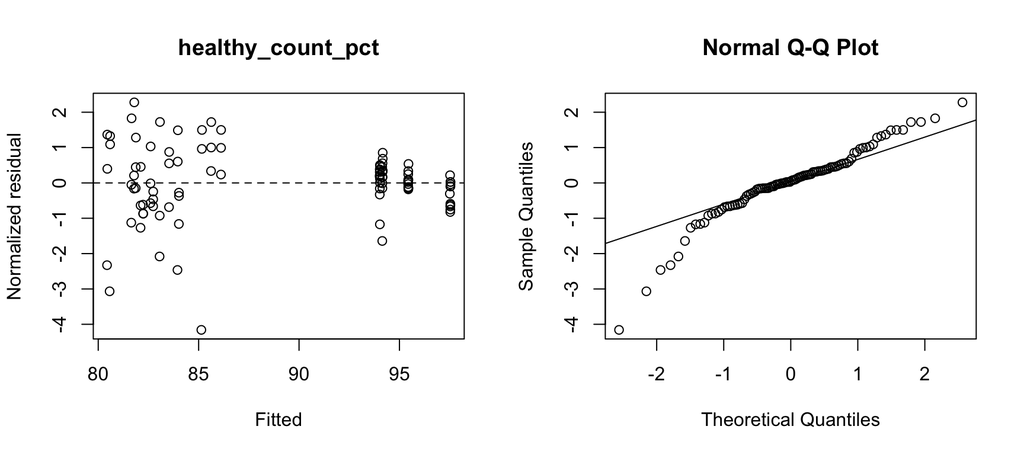

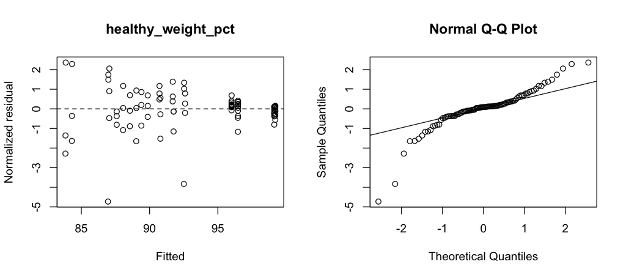

```r
models <- intensity_models
for (name in names(models)) {
  fit <- models[[name]]
  r <- residuals(fit, type="normalized")
  par(mfrow=c(1,2))
  plot(fitted(fit), r, xlab="Fitted", ylab="Normalized residual", main=name)
  abline(h=0, lty=2)
  qqnorm(r); qqline(r)
}
```

```r
par(mfrow=c(1,1))
```

These are preliminary Gaussian mixed models. Percentage responses require particular care with residual variance, normality and predictions outside 0-100. Consider beta-binomial (count percentage) or beta (weight percentage) models if needed. Cultivar is confounded with field; year effects do not identify a weather or alternate-bearing mechanism.